# 主机游戏数据分析

# 第七世代主机游戏销售情况研究

问题：假设现在一家处于第七世代的游戏公司想制作一款主机游戏，该怎么制定策略使得制作的游戏畅销？

根据已有的数据，可以将问题转化为：第七世代中，哪些类型的游戏在哪些地区的哪些平台上更有可能畅销？

对于游戏是否畅销，我们可以使用
$$每款游戏平均销售额=\frac{销售额}{游戏数量}$$
来衡量，该指标可以体现各个类型的游戏销售状况以及类型内游戏的竞争状况。该指标越大，从整体上说明游戏越畅销且内部竞争压力较小。

对于该问题，如果直接考虑全部分类，那将会使得分析变得十分困难，所以我们从整体出发，逐步细化，并作出对不同分类的筛选，从而达到尽可能利用数据的前提下减少最终分类数量的目的。

## 按类型分类

由此，我们可以先从整体上考虑以下问题：

- 1.第七世代各个类型中每款游戏平均销售额较高？
- 2.各个类型中每款游戏年平均销售额随世代的变化情况？

这两个问题分别涵盖了当下的信息以及历史趋势的信息，同时从这两个方面评估每款游戏平均销售额更合理。

由于该数据集只包含销量超过100,000的游戏，可以认为出现在该数据集中的游戏均为畅销游戏。所以利用该数据集讨论问题1，并作出下图。

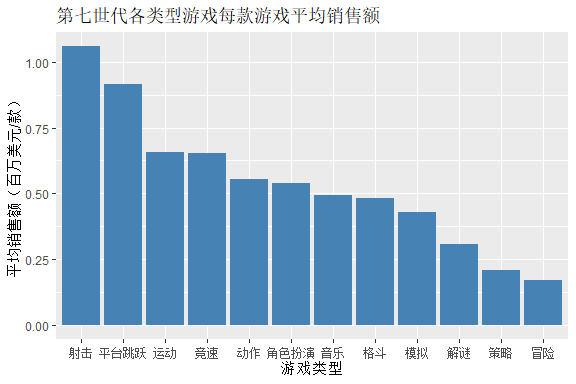

```r
Genre_ch = c('动作','冒险','格斗','音乐','平台跳跃','解谜','竞速','角色扮演','射击','模拟','运动','策略')
sales_console = sales_console %>%
                  mutate(Genre=factor(Genre))
levels(sales_console[,'Genre']) = Genre_ch

genre_sales7 = sales_console %>%
                filter(Generation==7) %>%
                group_by(Genre) %>%
                summarise(sums=sum(Global_Sales),duration=unique(duration))
genre_num7 = sales_console %>%
              filter(Generation==7) %>%
              group_by(Genre) %>%
              summarise(count=n())
genre_salesbynum7 = genre_sales7 %>%
                    merge(genre_num7,by='Genre') %>%
                    mutate(sc = sums/count) %>%
                    arrange(desc(sc)) %>%
                    mutate(Genre=factor(Genre,levels = Genre))

ggplot()+
  geom_bar(data=genre_salesbynum7,aes(x=Genre,y=sc),stat='identity',fill='steelblue')+
  labs(title = '第七世代各类型游戏每款游戏平均销售额',x='游戏类型',y='平均销售额（百万美元/款）')
```

```r
plat_sbn = genre_salesbynum7 %>%
            filter(Genre=='平台跳跃') %>%
            select(sc) %>%
            as.numeric()
sport_sbn = genre_salesbynum7 %>%
              filter(Genre=='运动') %>%
              select(sc) %>%
              as.numeric()
simulation_sbn = genre_salesbynum7 %>%
                  filter(Genre=='模拟') %>%
                  select(sc) %>%
                  as.numeric()
puzzle_sbn = genre_salesbynum7 %>%
              filter(Genre=='解谜') %>%
              select(sc) %>%
              as.numeric()
```

我们将前一名对后一名的每款平均销售额多的比率作为判断依据对游戏类型进行分类，其中平台跳跃游戏的每款平均销售额比运动游戏高38.97%，模拟游戏的每款平均销售额比解谜游戏高39.85%。综合上图可知，第七世代中，每款游戏平均销售额领先的游戏类型是射击和平台跳跃，较低的是解谜、策略、冒险，其它游戏类型均处于中等水平。射击、平台跳跃类游戏在该指标上领先，说明这些游戏类型当下受到玩家喜爱且竞品数量相对来说不多；运动到模拟类型游戏在该指标上处于中等水平，说明这些类型的游戏有一定的玩家基础，但由于竞品数量相对较多，导致平均销售额较低；指标处于较低水平的游戏类型的玩家数量较少，因此导致了平均销售额很低。

接着，对问题2进行讨论。针对问题2，我们使用
$$每款游戏年平均销售额=\frac{销售额}{游戏数量\times世代持续时间}$$
作为指标。该指标在每款游戏平均销售额的基础上消除了世代持续时间不同所带来的影响。同时，考虑到第四世代之前的数据缺失过多，因此只考虑第四世代开始的变化趋势。

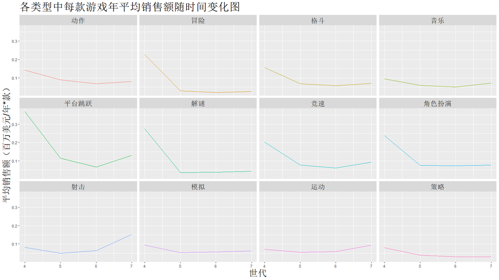

```r
genre_salesall = sales_console %>%
                  filter(Generation<=7,Generation>=4) %>%
                  group_by(Generation,Genre) %>%
                  summarise(sums=sum(Global_Sales),count=n(),duration=unique(duration)) %>%
                  mutate(spyn=sums/(count*duration))

ggplot()+
  geom_line(data=genre_salesall,aes(x=Generation,y=spyn,color=Genre))+
  facet_wrap(~Genre)+
  labs(title='各类型中每款游戏年平均销售额随时间变化图',x='世代',y='平均销售额（百万美元/年*款）')+
  theme(legend.position = 'none',
        plot.title = element_text(size=25),
        strip.text = element_text(size=16),
        axis.title.x = element_text(size=20),
        axis.title.y = element_text(size=20))
```

## 按平台分类

现在从平台的角度出发，进行整体上的分析。由于只考虑第七世代的平台，所以不需要考虑平均销售额随世代的变化，因此需要考虑的问题如下：

- 第七世代各平台游戏的每款游戏平均销售额？

对于该问题，使用每款游戏平均销售额作为指标。

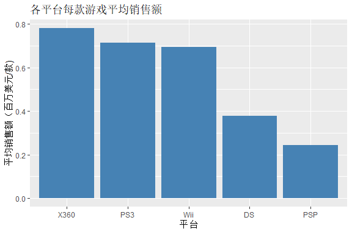

```r
plat_sales7 = sales_console %>%
                filter(Generation==7) %>%
                group_by(Platform) %>%
                summarise(sums=sum(Global_Sales),num=n()) %>%
                ungroup() %>%
                mutate(sbn=sums/num) %>%
                arrange(desc(sbn)) %>%
                mutate(Platform=factor(Platform,levels=Platform))

ggplot()+
  geom_bar(data=plat_sales7,aes(x=Platform,y=sbn),stat='identity',fill='steelblue')+
  labs(title='各平台每款游戏平均销售额',x='平台',y='平均销售额（百万美元/款)')
```

```r
x360_sbn = plat_sales7 %>%
            filter(Platform=='X360') %>%
            select(sbn) %>%
            as.numeric()
wii_sbn = plat_sales7 %>%
            filter(Platform=='Wii') %>%
            select(sbn) %>%
            as.numeric()
ds_sbn = plat_sales7 %>%
          filter(Platform=='DS') %>%
          select(sbn) %>%
          as.numeric()
```

我们将前一名对后一名的每款平均销售额多的比率作为判断依据来比较平台上游戏销售情况的好坏，其中X360平台的每款游戏平均销售额比Wii高12.54%，而Wii平台的每款游戏平均销售额比DS平台高83.06%。综合上图可以，认为X360、PS3、Wii平台的每款游戏平均销售额差距很小，而Wii平台的每款游戏平均销售额与DS差距显著。**所以可以认为在X360、PS3、Wii平台上发售的游戏更有可能获得较高销售额。**

## 按地区分类

按地区分类可以考虑以下两个问题：

- 1.第七世代各平台游戏的每款游戏平均销售额
- 2.各平台游戏的每款游戏年平均销售额随世代的变化情况

和按类型分类的情况同理，讨论问题1时使用每款游戏平均销售额作为指标。

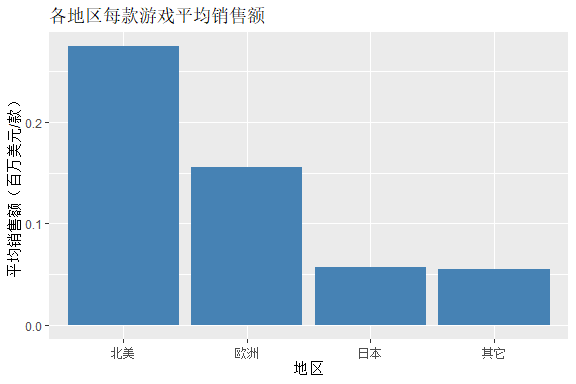

```r
NA_sales7 = long_reg_sales7 %>%
              filter(variable=='北美') %>%
              select(sbn) %>%
              as.numeric()

EU_sales7 = long_reg_sales7 %>%
              filter(variable=='欧洲') %>%
              select(sbn) %>%
              as.numeric()
JP_sales7 = long_reg_sales7 %>%
              filter(variable=='日本') %>%
              select(sbn) %>%
              as.numeric()
```

我们将前一名对后一名的每款平均销售额多的比率作为判断依据来比较地区间游戏销售情况的好坏，其中北美地区的每款游戏平均销售额比欧洲高76.94%，欧洲的该指标比日本高169.63%。这说明当前地区间的差异十分明显，其中销售情况最好的是北美地区，其次是欧洲地区，较差的是日本和其它地区。

接下来考虑问题2，从发展的角度来看待各个地区的销售情况，使用的指标是每款游戏年平均销售额。

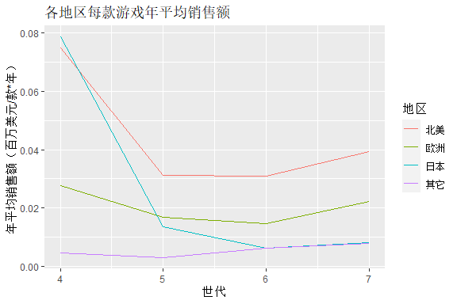

```r
long_reg_sales = sales_console %>%
                  group_by(Generation) %>%
                  summarise(sNA=sum(NA_Sales),sEU=sum(EU_Sales),sJP=sum(JP_Sales),sO=sum(Other_Sales),num=n(),duration=unique(duration)) %>%
                  mutate(sbnNA=sNA/(num*duration),sbnEU=sEU/(num*duration),sbnJP=sJP/(num*duration),sbnO=sO/(num*duration)) %>%
                  select(Generation,sbnNA,sbnEU,sbnJP,sbnO) %>%
                  melt(id.vars='Generation') %>%
                  filter(Generation!=8,Generation>=4)
ggplot()+
  geom_line(data=long_reg_sales,aes(x=Generation,y=value,color=variable))+
  labs(title='各地区每款游戏年平均销售额',x='世代',y='年平均销售额（百万美元/款*年）')+
  scale_color_discrete(name='地区',labels = c('北美','欧洲','日本','其它'))
```

可以看到北美地区、欧洲地区在较近世代的每款游戏年平均销售额指标有上升的趋势，可以认为在这两个地区的销售额还未达到瓶颈，而日本地区和其它地区的该指标表现平稳，且值较小。因此从发展的角度也可以认为北美、欧洲地区会有更好的销售表现

**总的来说，从现状和发展这两个角度来看，北美、欧洲地区的游戏都更有可能畅销**

## 按平台-类型分类

在对各类型整体销售情况进行讨论的基础上，接下来讨论更细致的问题：

- 第七世代中，上述可能畅销的游戏类型在各平台的每款游戏平均销售额较高的有哪些？

对于这个问题，仍然利用每款游戏平均销售额作为指标。出于对分析的完整性和便利性的权衡，此处对选定的类型及所有平台进行交叉，计算每个交叉项的指标值，得到下方热图。

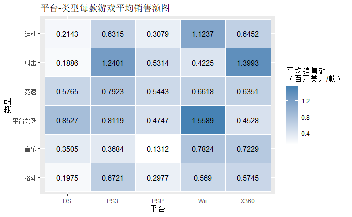

```r
sales_gp7 = sales_console %>%
              filter(Generation==7) %>%
              mutate(Platform=factor(Platform)) %>%
              group_by(Platform,Genre) %>%
              summarise(sum = sum(Global_Sales),num=n()) %>%
              ungroup() %>%
              filter(Genre %in% c('射击','平台跳跃','运动','竞速','音乐','格斗')) %>%
              mutate(sbn=sum/num) %>%
              select(-sum,-num) %>%
              mutate(is_selected=(sbn>=mean(sbn)))


ggplot()+
  geom_tile(data=sales_gp7,aes(x=Platform,y=Genre,fill=sbn),color='white')+
  scale_fill_gradient(low='white',high='steelblue')+
  geom_text(data=sales_gp7,aes(x=Platform,y=Genre,label=round(sbn,4)))+
  labs(title='平台-类型每款游戏平均销售额图',x='平台',y='类型')+
  guides(fill=guide_colorbar(title = '平均销售额\n（百万美元/款）'))
```

```r
NA
```

取平均值作为标准作为判断标准，选取高于平均值的平台-类型作为备选组合，所有平台-类型的平均值为0.6244百万美元/款。根据该标准选取的组合如下：

```r
sales_gp7_sel1 = sales_gp7 %>%
                  filter(is_selected==T) %>%
                  select(Platform,Genre)

display_gp7_sel = sales_gp7_sel1 %>%
                    group_by(Genre) %>%
                    select(Genre,Platform) %>%
                    arrange(Genre)
colnames(display_gp7_sel)=c('类别','平台')
display_gp7_sel
```

| 类别 | 平台 |
| --- | --- |
| 格斗 | PS3 |
| 音乐 | Wii |
| 音乐 | X360 |
| 平台跳跃 | DS |
| 平台跳跃 | PS3 |
| 平台跳跃 | Wii |
| 竞速 | PS3 |
| 竞速 | Wii |
| 竞速 | X360 |
| 射击 | PS3 |

[output cut: 4 more lines]

这些组合中包含的游戏类型正好是此前对游戏类型单因素分析得出集合的子集。

## 按地区-类型分类

接下来从地区的角度来考虑下列问题：

- 1.第七世代各地区-类型组合的每款游戏平均销售额？
- 2.各地区-类型组合的每款游戏年平均销售额随世代的变化？

利用每款游戏平均销售额来考虑问题1。根据对地区销售情况的研究，并出于对分析的完整性和便利性的权衡，此处对选定的类型及北美、欧洲地区进行交叉，计算每个交叉项的指标值，得到下方热图。

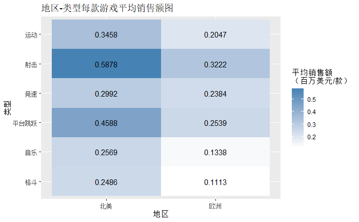

```r
sales_gr7 = sales_console %>%
              filter(Generation==7,Genre %in% c('射击','平台跳跃','运动','竞速','音乐','格斗')) %>%
              group_by(Genre) %>%
              summarise(sNA=sum(NA_Sales),sEU=sum(EU_Sales),sJP=sum(JP_Sales),sOther=sum(Other_Sales),count=n()) %>%
              ungroup() %>%
              mutate(sbnNA=sNA/count,sbnEU=sEU/count,sbnJP=sJP/count,sbnO=sOther/count) %>%
              select(Genre,sbnNA,sbnEU,sbnJP,sbnO) %>%
              melt(id.vars='Genre') %>%
              filter(variable %in% c('sbnNA','sbnEU'))
ggplot()+
  geom_tile(data=sales_gr7,aes(x=variable,y=Genre,fill=value))+
  scale_fill_gradient(low = 'white',high='steelblue')+
  scale_x_discrete(labels=c('北美','欧洲'))+
  geom_text(data=sales_gr7,aes(x=variable,y=Genre,label=round(value,4)))+
  labs(title='地区-类型每款游戏平均销售额图',x='地区',y='类型')+
  guides(fill=guide_colorbar(title = '平均销售额\n（百万美元/款）'))
```

以所有组合的每款游戏平均销售额的均值作为标准，将高于均值的组合作为备选项，经计算，得到0.2884百万美元/款，以下给出被选中的组合：

```r
threshhold_gr7 = mean(sales_gr7[,'value'])
displaytab_gr7 = sales_gr7 %>%
                  filter(value>=threshhold_gr7) %>%
                  select(Genre,variable)
colnames(displaytab_gr7)=c('类别','地区')
levels(displaytab_gr7[,'地区'])=c('北美','欧洲','日本','其它')
displaytab_gr7
```

| 类别 | 地区 |
| --- | --- |
| 平台跳跃 | 北美 |
| 竞速 | 北美 |
| 射击 | 北美 |
| 运动 | 北美 |
| 射击 | 欧洲 |

接着考虑问题2，从可行性的角度出发，我们在此只考虑以上被选中的组合是否还有发展前景。因此考虑以上几种组合的每款游戏年平均销售额指标。

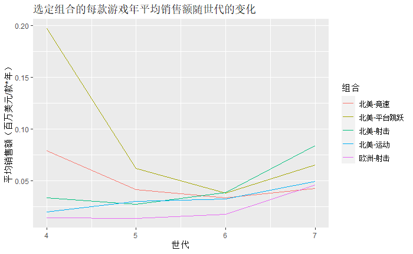

```r
sel_gr = sales_gr7 %>%
          filter(value>=threshhold_gr7) %>%
          select(Genre,variable)
sales_grall = sales_console %>%
                filter(Generation!=8,Generation>=4) %>%
                group_by(Generation,Genre) %>%
                summarise(sNA=sum(NA_Sales),sEU=sum(EU_Sales),sJP=sum(JP_Sales),sO=sum(Other_Sales),num=n(),duration=unique(duration)) %>%
                ungroup() %>%
                mutate(sbnNA=sNA/(num*duration),sbnEU=sEU/(num*duration),sbnJP=sJP/(num*duration),sbnO=sO/(num*duration)) %>%
                select(Generation,Genre,sbnNA,sbnEU,sbnJP,sbnO) %>%
                melt(id.var=c('Generation','Genre')) %>%
                merge(sel_gr,by=c('Genre','variable'))

levels(sales_grall[,'variable']) = c('北美','欧洲','日本','其它')
sales_grall = sales_grall %>%
                mutate(comb=paste(variable,Genre,sep='-'))

ggplot()+
  geom_line(data=sales_grall,aes(x=Generation,y=value,color=comb))+
  labs(title='选定组合的每款游戏年平均销售额随世代的变化',x='世代',y='平均销售额（百万美元/款*年）')+
  guides(color=guide_legend(title = '组合'))
```

可以看到在北美地区，竞速类游戏接近第七世代的增长率最低。因此将其从备选的地区-类型组合中去除。最终留下的组合名单如下：

```r
fdisplaytab_gr7 = displaytab_gr7[-2,]
fdisplaytab_gr7
```

|  | 类别 | 地区 |
| --- | --- | --- |
| 1 | 平台跳跃 | 北美 |
| 3 | 射击 | 北美 |
| 4 | 运动 | 北美 |
| 5 | 射击 | 欧洲 |

## 最终类型-地区-平台组合

通过以上的分析，最终将类型-地区-平台组合减少到了10类，名单如下：

```r
semifinal_sel = fdisplaytab_gr7 %>%
                  merge(display_gp7_sel,by='类别')
semifinal_sel
```

| 类别 | 地区 | 平台 |
| --- | --- | --- |
| 平台跳跃 | 北美 | Wii |
| 平台跳跃 | 北美 | DS |
| 平台跳跃 | 北美 | PS3 |
| 射击 | 北美 | PS3 |
| 射击 | 北美 | X360 |
| 射击 | 欧洲 | PS3 |
| 射击 | 欧洲 | X360 |
| 运动 | 北美 | PS3 |
| 运动 | 北美 | Wii |
| 运动 | 北美 | X360 |

根据这个名单，可以直接对每一类的每款游戏平均销售额进行排序。

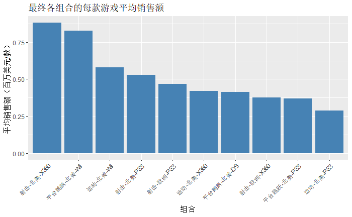

```r
colnames(semifinal_sel)=c('Genre','Region','Platform')
final_set = sales_console %>%
              filter(Generation==7) %>%
              group_by(Genre,Platform) %>%
              summarise(sNA=sum(NA_Sales),sEU=sum(EU_Sales),sJP=sum(JP_Sales),sOther=sum(Other_Sales),count=n()) %>%
              ungroup() %>%
              mutate(北美=sNA/count,欧洲=sEU/count,日本=sJP/count,其它=sOther/count) %>%
              select(Genre,Platform,北美,欧洲,日本,其它) %>%
              melt(id.vars=c('Genre','Platform'),variable.name='Region') %>%
              merge(semifinal_sel,by=c('Genre','Region','Platform')) %>%
              mutate(genre=paste(Genre,Region,sep='-')) %>%
              mutate(final_genre=paste(genre,Platform,sep='-')) %>%
              arrange(desc(value)) %>%
              mutate(final_genre=factor(final_genre,levels=final_genre))

ggplot()+
  geom_bar(data=final_set,aes(x=final_genre,y=value),stat='identity',fill='steelblue')+
  labs(title = '最终各组合的每款游戏平均销售额',x='组合',y='平均销售额（百万美元/款）')+
  theme(axis.text.x = element_text(angle = 45,hjust = 1))
```

```r
pnw = final_set %>%
      filter(final_genre=='平台跳跃-北美-Wii') %>%
      select(value) %>%
      as.numeric()

spw = final_set %>%
      filter(final_genre=='运动-北美-Wii') %>%
      select(value) %>%
      as.numeric()
```

以前一名对后一名的每款平均销售额多的比率未判断依据来比较各个组合销售情况的好坏。可以看到在北美X360平台上发售的射击类游戏和在北美Wii平台上发售的平台跳跃游戏的每款游戏平均销售额指标远高于其它组合。其中在北美Wii平台上发售的平台跳跃游戏的每款游戏平均销售额比在北美Wii平台上发售的运动游戏高42.69%。**所以第七世代中，在北美X360平台上发售的射击类游戏和在北美地区Wii平台上发售的平台跳跃游戏更有可能畅销。**

# 结论与反思

## 结论

- 平均游戏销量与平均游戏数量的变化趋势一致，在第七世代迎来高峰。第八世代发售的优秀游戏数量远不如第七世代，相应的销量也远不如第七世代。
- 第七世代中，在北美X360平台上发售的射击类游戏和在北美地区Wii平台上发售的平台跳跃游戏更有可能畅销。

## 不足

- 分析过程中是逐步对类别进行筛选，且前一次筛选掉的类不会出现在后续分析中，可能造成最终结果不是全局最优的。要考虑全局最优需要使用模型。
- 第四世代之前的数据解释不清楚，只能舍弃这些数据再进行分析，这使得可利用的信息减少了，并可能导致结论不够完整。